# EDA를 기반으로 한 심장마비 데이터 분석 - 202055157 황도현

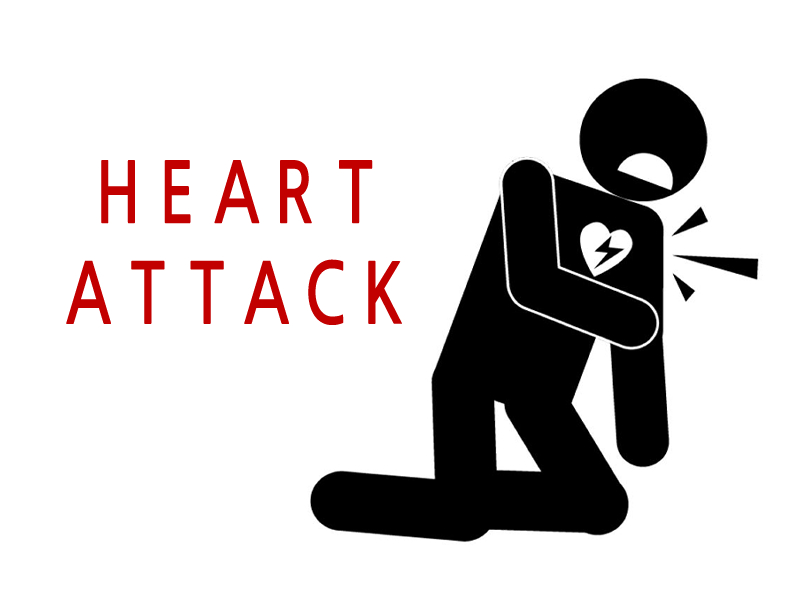

## 주제: 어떤 사람이 심장마비에 취약할까?

### 데이터셋: ‘심장 마비 분류를 위한 데이터셋’

(출처: [Heart Attack Analysis & Prediction Dataset | Kaggle](https://www.kaggle.com/rashikrahmanpritom/heart-attack-analysis-prediction-dataset))

### 탐구 질문

- 데이터셋에 있는 요인 중 어떤 요인이 심장마비에 가장 큰 영향을 미치는가? 그 이유는?
- 각 요인들은 서로 어떤 상관관계를 가지고 있을까?

### 분석할 변수(요인)

: 나이, 성별, 주요 혈관의 수, 혈압, 콜레스테롤, 혈당 등 13개 요인(변수)

## EDA: 탐색적 데이터 분석 (Exploratory Data Analysis)

(EDA 출처: [EDA (Exploratory Data Analysis) 탐색적 데이터 분석](https://eda-ai-lab.tistory.com/13))  
(EDA 그래프 출처:https://www.kaggle.com/vipin20/heart-attack-analysis-eda-91-score)  
1) **정의**: 수집한 데이터가 들어왔을 때, 이를 다양한 각도에서 관찰하고 이해하는 과정. 데이터를 분석하기 전에 그래프나 통계적인 방법으로 자료를 직관적으로 바라보는 과정.  
2) **필요한 이유**:

- 데이터의 분포 및 값을 검토함으로써 데이터가 표현하는 현상을 더 잘 이해하고, 데이터에 대한 잠재적인 문제를 발견할 수 있다.  
  이를 통해, 본격적인 분석에 들어가기에 앞서 데이터의 수집을 결정할 수 있다.
- 다양한 각도에서 살펴보는 과정을 통해 문제 정의 단계에서 미쳐 발생하지 못했을 다양한 패턴을 발견하고,  
  이를 바탕으로 기존의 가설을 수정하거나 새로운 가설을 세울 수 있다.

## Heart Attack(심장마비) - EDA

### 1. Introduction(도입부)

1.1 Data Dictionary(분석할 변수(요인))  
1.2 Task(해야 할 일)

### 2. Preparation(준비과정)

2.1 Packages(설치한 패키지)  
2.2 Data(사용할 데이터)  
2.3 Understanding Data(데이터 이해)

### 3. Exploratory Data Analysis(탐색적 데이터 분석)

3.1 Bivariate Analysis(2변수 분석)

### 4. Data Preprocessing(데이터 처리)

4.1 t-test (그룹 간 평균의 비교)  
4.2 상관관계의 유의성 검정  
4.3 카이 제곱 검정(교차표(cross-tab) 생성 및 그룹간 빈도 비교)  
4.4 전체 데이터에서 검정하기

### 5. 결론

### 6. Q&A(질의 응답)

## 1. Introduction(도입부)

### 1.1 Data Dictionary(분석할 변수(요인))

##### 6) trtbps : resting blood pressure (in mm Hg) (휴식 혈압 (mm Hg))

##### 7) chol : cholestoral in mg/dl fetched via BMI sensor (혈청 콜레스테롤 (mg / dl))

##### 8) fbs : (fasting blood sugar > 120 mg/dl) (1 = true; 0 = false) (공복 혈당 (120mg / dl))

##### 9) rest_ecg : resting electrocardiographic results (휴식 심전도 결과)

- Value 0: normal(정상)
- Value 1: having ST-T wave abnormality (T wave inversions and/or ST elevation or depression of > 0.05 mV)(ST-T 파 이상)
- Value 2: showing probable or definite left ventricular hypertrophy by Estes' criteria(좌심실 비대)

#### 10) thalach : maximum heart rate achieved(탈륨 스트레스 테스트 중 달성 된 심박수 최대치)

##### 11) output : 0= less chance of heart attack (심장마비에 걸릴 낮은 확률) 1= more chance of heart attack (심장마비에 걸릴 높은 확률)

### 1.2 Task(해야 할 일)

EDA(탐색적 데이터 분석)를 통해 실행하고, 특정 인물이 심장 마비에 취약한지 그렇지 않은지 예측해보자.

## 2. Preparation(준비과정)

### 2.1 Packages(설치한 패키지)

```python
#필요한 모듈 라이브러리를 불러온다.
import pandas as pd
from pandas import Series, DataFrame
import numpy as np
import numpy.random as random
import matplotlib.pyplot as plt
import matplotlib as mpl
import seaborn as sns
import scipy as sp
import scipy.stats as stats

# 그래프를 주피터 노트북에 그리기 위한 설정
%matplotlib inline

# 자릿수 지정
%precision 3

#경고 메시지 무시
import warnings
warnings.filterwarnings("ignore")
```

### 2.2 Data(사용할 데이터)

```python
#사용할 데이터를 csv파일로 읽는다
df = pd.read_csv("heart.csv")
```

### 2.3 Understanding Data(데이터 이해)

#### 2.3.1 The shape of the data(데이터의 형태)

```python
#데이터의 열과 행 개수를 구한다.
print("The shape of the dataset is : ", df.shape)
```

```
The shape of the dataset is :  (303, 14)
```

#### 2.3.2 Preview of the first 5 rows of the data(5열까지만 데이터 미리보기)

```python
#head 함수를 사용해서 앞부분 데이터를 살펴본다.
df.head()
```

|  | age | sex | cp | trtbps | chol | fbs | restecg | thalachh | exng | oldpeak | slp | caa | thall | output |
| --- | --- | --- | --- | --- | --- | --- | --- | --- | --- | --- | --- | --- | --- | --- |
| 0 | 63 | 1 | 3 | 145 | 233 | 1 | 0 | 150 | 0 | 2.3 | 0 | 0 | 1 | 1 |
| 1 | 37 | 1 | 2 | 130 | 250 | 0 | 1 | 187 | 0 | 3.5 | 0 | 0 | 2 | 1 |
| 2 | 41 | 0 | 1 | 130 | 204 | 0 | 0 | 172 | 0 | 1.4 | 2 | 0 | 2 | 1 |
| 3 | 56 | 1 | 1 | 120 | 236 | 0 | 1 | 178 | 0 | 0.8 | 2 | 0 | 2 | 1 |
| 4 | 57 | 0 | 0 | 120 | 354 | 0 | 1 | 163 | 1 | 0.6 | 2 | 0 | 2 | 1 |

#### 2.3.3 Checking the number of unique values in each column(각 열 별 단일값 검출하기)

```python
#딕셔너리를 생성해 df 속 개별 컬럼 내에 각각의 값이 중복되지 않게 나온 횟수를 세고 딕셔너리에 저장하기.
dict = {}
for i in list(df.columns):
    dict[i] = df[i].value_counts().shape[0]
```

```python
df.columns
```

```
Index(['age', 'sex', 'cp', 'trtbps', 'chol', 'fbs', 'restecg', 'thalachh',
       'exng', 'oldpeak', 'slp', 'caa', 'thall', 'output'],
      dtype='object')
```

```python
dict
```

```
{'age': 41,
 'sex': 2,
 'cp': 4,
 'trtbps': 49,
 'chol': 152,
 'fbs': 2,
 'restecg': 3,
 'thalachh': 91,
 'exng': 2,
 'oldpeak': 40,
 'slp': 3,
 'caa': 5,
 'thall': 4,
 'output': 2}
```

```python
#transpose 함수를 이용해 가로와 세로 셀 범위를 바꾸어 반환(column에 있었던 요인들을 row로 보낸다.)
pd.DataFrame(dict,index=["unique count"]).transpose()
```

|  | unique count |
| --- | --- |
| age | 41 |
| sex | 2 |
| cp | 4 |
| trtbps | 49 |
| chol | 152 |
| fbs | 2 |
| restecg | 3 |
| thalachh | 91 |
| exng | 2 |
| oldpeak | 40 |
| slp | 3 |
| caa | 5 |
| thall | 4 |
| output | 2 |

#### 2.3.4 Separating the columns in categorical and continuous(카테고리와 연속성에 따라 열 분류하기)

```python
cat_cols = ['sex','exng','caa','cp','fbs','restecg','slp','thall']
con_cols = ["age","trtbps","chol","thalachh","oldpeak"]
target_col = ["output"]
print("The categorial cols are : ", cat_cols)
print("The continuous cols are : ", con_cols)
print("The target variable is :  ", target_col)
```

```
The categorial cols are :  ['sex', 'exng', 'caa', 'cp', 'fbs', 'restecg', 'slp', 'thall']
The continuous cols are :  ['age', 'trtbps', 'chol', 'thalachh', 'oldpeak']
The target variable is :   ['output']
```

#### 2.3.5 Summary statistics(수치 요약)

```python
#describe()를 이용해 continuous cols의 데이터 요약본을 보고, transpose()를 이용해 열과 행를 바꾼다.
#(categorial cols는 데이터 요약본을 만들기에 적절치 않다.)
df[con_cols].describe().transpose()
```

|  | count | mean | std | min | 25% | 50% | 75% | max |
| --- | --- | --- | --- | --- | --- | --- | --- | --- |
| age | 303.0 | 54.366337 | 9.082101 | 29.0 | 47.5 | 55.0 | 61.0 | 77.0 |
| trtbps | 303.0 | 131.623762 | 17.538143 | 94.0 | 120.0 | 130.0 | 140.0 | 200.0 |
| chol | 303.0 | 246.264026 | 51.830751 | 126.0 | 211.0 | 240.0 | 274.5 | 564.0 |
| thalachh | 303.0 | 149.646865 | 22.905161 | 71.0 | 133.5 | 153.0 | 166.0 | 202.0 |
| oldpeak | 303.0 | 1.039604 | 1.161075 | 0.0 | 0.0 | 0.8 | 1.6 | 6.2 |

#### 2.3.6 Missing values(누락값)

```python
#isnull().sum()을 이용해 결측값이 있는지, 그리고 결측값이 있다면 결측값의 개수가 몇 개인지 확인한다.
#isnull() 메소드는 관측치가 결측이면 True, 결측이 아니면 False의 boollean 값을 반환
df.isnull().sum()
```

```
age         0
sex         0
cp          0
trtbps      0
chol        0
fbs         0
restecg     0
thalachh    0
exng        0
oldpeak     0
slp         0
caa         0
thall       0
output      0
dtype: int64
```

## 3. Exploratory Data Analysis(탐색적 데이터 분석)

### 3.1 Bivariate Analysis(2변수 분석)

#### 3.1.1 Correlation matrix of continuous features(연속적 요인의 상관관계 매트릭스)

```python
df_corr = df[con_cols].corr().transpose()
df_corr
```

|  | age | trtbps | chol | thalachh | oldpeak |
| --- | --- | --- | --- | --- | --- |
| age | 1.000000 | 0.279351 | 0.213678 | -0.398522 | 0.210013 |
| trtbps | 0.279351 | 1.000000 | 0.123174 | -0.046698 | 0.193216 |
| chol | 0.213678 | 0.123174 | 1.000000 | -0.009940 | 0.053952 |
| thalachh | -0.398522 | -0.046698 | -0.009940 | 1.000000 | -0.344187 |
| oldpeak | 0.210013 | 0.193216 | 0.053952 | -0.344187 | 1.000000 |

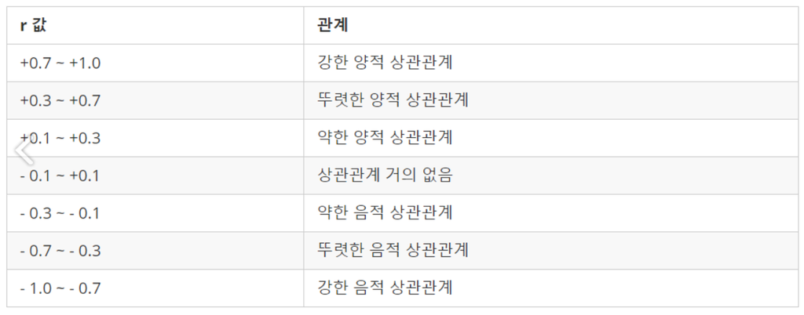

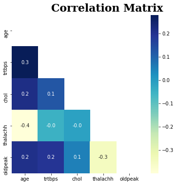

```python
fig = plt.figure(figsize=(6,6))
gs = fig.add_gridspec(1,1)
gs.update(wspace=0.3, hspace=0.15)
ax0 = fig.add_subplot(gs[0,0])
color_palette = ["#5833ff","#da8829"]
mask = np.triu(np.ones_like(df_corr))
ax0.text(1.5,-0.1,"Correlation Matrix",fontsize=22, fontweight='bold', fontfamily='serif', color="#000000")
df_corr = df[con_cols].corr().transpose()
sns.heatmap(df_corr,mask=mask,fmt=".1f",annot=True,cmap='YlGnBu')
plt.show()
```